# Stress mentale nei studenti e meccanismi di coping

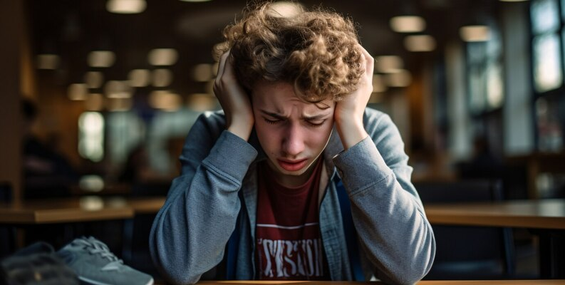

# Introduzione

## Cos’è lo stress mentale nei giovani?

Lo scopo del progetto è quello di eseguire un’analisi sui fattori che possono causare questo fenomeno nei giovani tra i 18-30 anni. Inoltre, analizzeremo anche quali meccanismi di coping i giovani utilizzano per alleviare lo stress.

## Fonte dei dati

I dati analizzti in questo progetto sono stati scaricati da Kaggle, un ambiente di lavoro in cui sono presenti diversi database pubblici.

Questo set di dati fornisce informazioni sui livelli di stress mentale sperimentati dagli studenti, nonché sui meccanismi di coping che utilizzano per gestirlo. I dati includono una varietà di fattori, come il rendimento scolastico, le abitudini di vita, le influenze sociali e gli aspetti relativi alla salute mentale, nonché le strategie degli studenti per gestire lo stress.

# Analisi dei dati

## Analisi strutturale

La tabella presenta diverse colonne nella struttura del dataset preso in esame, le quali riportano diversi attributi, sia di tipo categorico che ordinale.

```
INFORMAZIONI GENERALI SUL DATASET PRESO IN ESAME

 Numero degli studenti     760
 Eta'minima                18
 Eta' massima              30

Divisi per Genere:
      Genere
     Agender
    Bigender
      Female
 Genderfluid
 Genderqueer
        Male
  Non-binary
  Polygender

RANGE DI VALORI
 GPA:                    0 - 4
 Supporto familiare:     1 - 5
 Stress finanziario:     1 - 5
 Pressione dei pari:     1 - 5
 Stress relazionale:     1 - 5
 Stress mental:          1 - 10
 Qualità della dieta:    1 - 5
 Distorsioni cognitive:  1 - 5
 Uso di stostanze:       1 - 5


Studenti che effettuano sedute di consulenza:
 Consulenza   Numero Studenti
         No               387
        Yes               373

Anamensi familiare di problemi di salute mentale:
 Condizione   Numero Studenti
         No               376
        Yes               384

Condizioni mediche degli studenti:
 Condizione   Numero Studenti
         No               407
        Yes               353
```

## Analisi relazionale

In questa sezione, ci concentremo sulla relazione tra i diversi dati presenti nel database, proprio per evidenziare come diversi fattori incidono sugli indici di stress di uno studente.

### E’ possibile classificare l’indice di stress mentale in base al genere?

Nella visualizzazione sottostante, l’obiettivo è quello di mostrare come sono distributi i diversi studenti con particolare indice di stress, in base al loro genere. I dati raccolti mostrano una maggioranza di studenti di genere femminile e maschile, ed inoltre, a prima vista, questi due generi sono distribuiti allo stesso modo. Questo può voler dire che nè il genere maschile e nè il genere femminili sono fattori che possono influenzare lo stress nello studente.

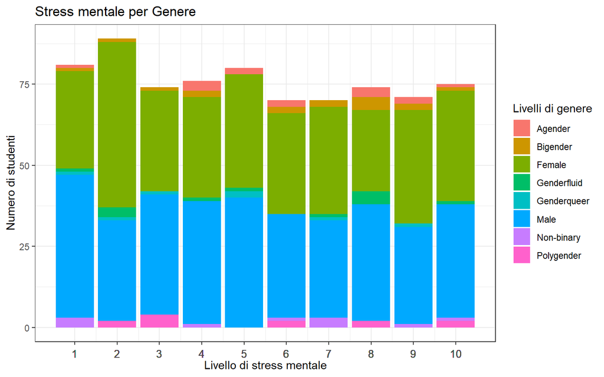

### E’ possibile classificare l’indice di stress mentale in base all’età?

In questo caso, l’obiettivo è quello di analizzare come l’età dello studente potrebbe influenzare sul suo indice di stress.

In primo luogo, possiamo notare che un’alta frequenza di indice di stress di valore 10 è presente negli studenti di età 18 e 30.

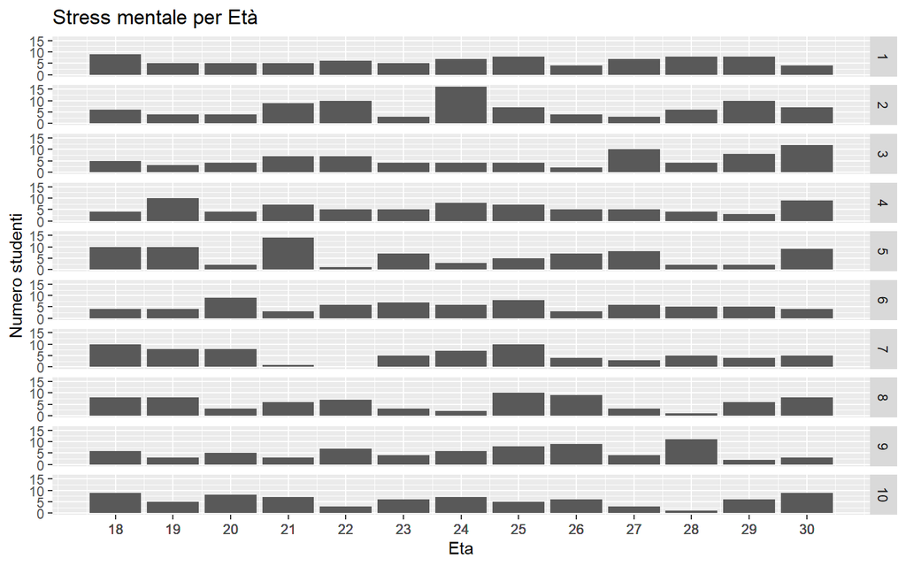

### Le ore di studio influenzano il rendimento accademico(GPA)?

In seguito, è stato analizzato il rendimento accademico degli studenti proporzionato alle ore di studio impiegate, con lo scopo di visualizzare quanto le ore di studio influenzino sul rendimento finale dello studente.

```
  Gpa      Ore
1   0 29.85714
2   1 28.66423
3   2 28.72483
4   3 28.24118
5   4 30.23776
```

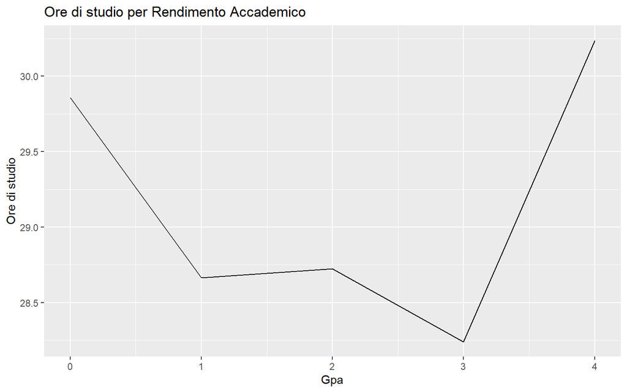

In effetti, dal grafico è possibile notare come i due livelli di rendimento estremi, variano tra loro per un valore di circa 0.5, rispetto ai livelli intermedi. Infatti, con ciò è possibile affermare che non sempre le troppe ore impiegate incidono sul rendimento finale.

### Le distorsioni cognitive possono influenzare il rendimento accademico(GPA)?

Molto spesso il rendimento accademico di uno studente può essere ostacolato da diversi fattori, come ad esempio distorsioni cognitive. Alcune di queste possono essere

- Pensiero dicotomico (o bianco/nero)
- Generalizzazione eccessiva
- Esclusione del positivo
- Il ragionamento emotivo (basare le proprie convinzioni sulle emozioni).

Il più delle volte, queste distorsioni compromettono il reale rendimento dello studente, portandolo ad uno stato elevato di stress mentale e riduzione del rendimento accademico.

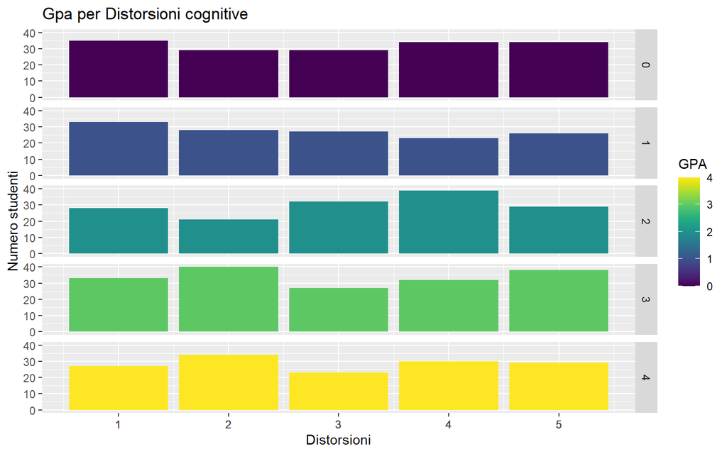

E’ possibile osservare, dove vi è un elevato livello di distorsioni cognitive, sale il numero di studenti con GPA basso. Allo stesso modo, alcuni casi in cui si ha indice basso di distorsioni cognitive, il numero di studenti con livello di GPA basso sembrerebbe più elevato rispetto al caso di GPA alto. Inoltre, è possibile osservare che ciò non vale per tutti i casi, ma in alcune situazioni, nonostante il livello di distorsione è basso, il numero di studenti con GPA elevato risulta più basso rispetto a casi in cui i livelli di distorsioni sono più elevati. In questo caso, potrebbe vuol dire che il livello di GPA non è solo condizionato da questi schemi di pensiero, ma da altre cause come le ore di studio oppure le ore di sonno impiegate.

### Qual è l’andamento degli indice di stress mentale?

Questo grafico sull’andamento ci permette di visualizzare come sono divisi il numero degli studenti per ogni livello di stress.

Gli indici con un numero minore di studenti risultano gli indici 6 e 7.

Mentre la maggior parte degli studenti possiedono un indice di stress pari a 2.

Mentre per i livelli maggiori, il numero di studenti rimane più o meno costante, con picchi sull’indice 5 e l’indice 10.

```
# A tibble: 10 × 2
   stress_mental count
           <dbl> <int>
 1             1    81
 2             2    89
 3             3    74
 4             4    76
 5             5    80
 6             6    70
 7             7    70
 8             8    74
 9             9    71
10            10    75
```

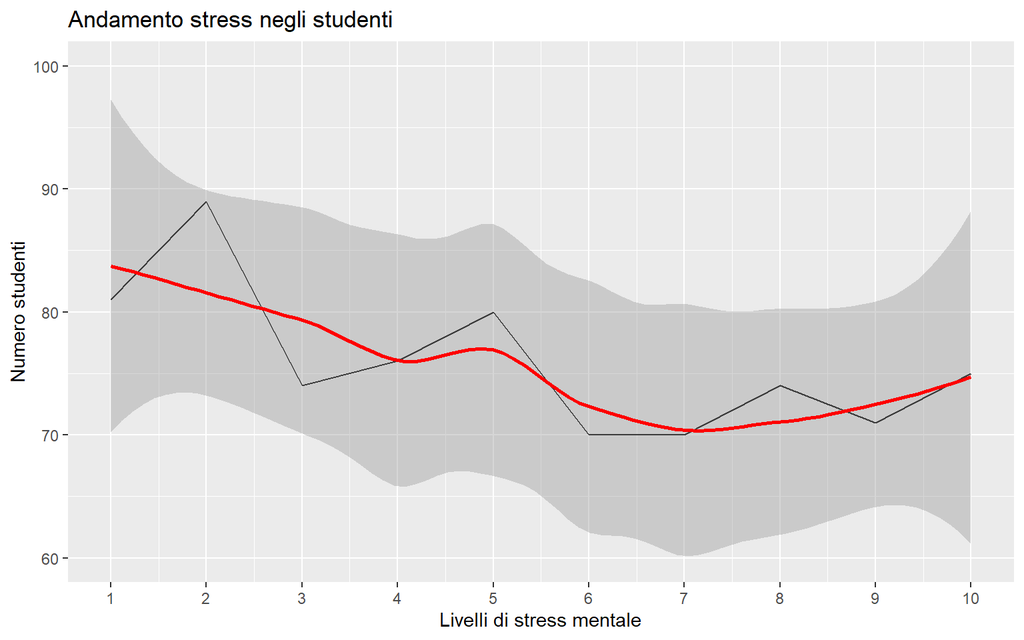

### Lo stress mentale da cosa può essere influenzato?

La presenza di stress mentale negli studenti può derivare da altri fattori di stress, come

- stress finannziario
- stress derivato dal paragonarsi con gli altri (parità)
- stress relazionale

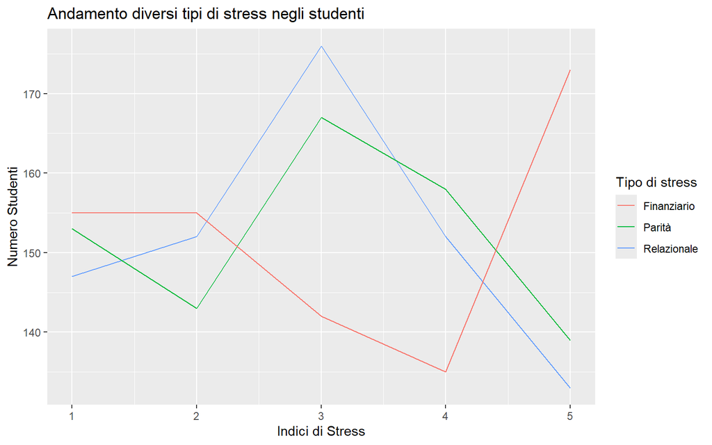

Con il seguente grafico, è possibile visualizzare l’andamento del numero degli studenti per ognuno dei diversi fattori di stress. Infatti, è possibile notare come un gran numero di studenti presenta un indice 5 di stress finanziario, mentre gli altri due fattori raggiungono un numero elevato di studenti negli indici intermedi.

### Quanti studenti effettuano delle consulenze?

E’ importante, quando si è in una situazione di stress sopratutto per gli studenti, effettuare delle consulenze con medici specializzati, i quali possono aiutare nel affrontare al meglio situazioni che portano ad alti livelli di stress.

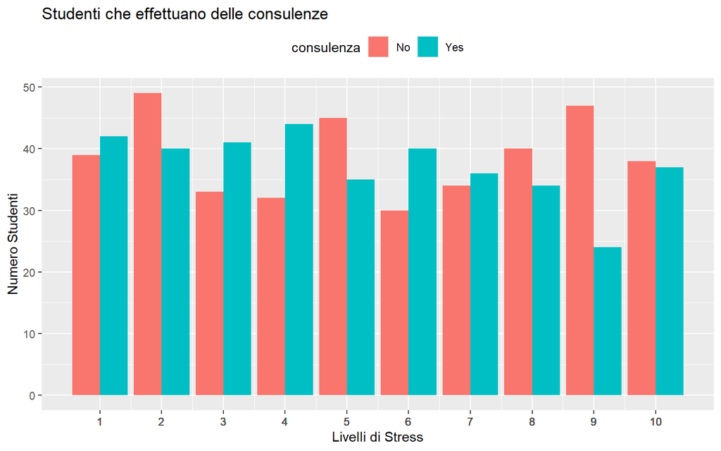

### Vi è una relazione tra esercizio fisico e qualità della dieta?

Negli studenti è importante mantenere una giusta qualità della dieta, associata con dell’esercizio fisico, poichè la loro combinazione permette di alleviare lo stress mentale.

Infatti, il seguente grafico mostra come i diversi studenti combinano ore di esercizio fisico a settimana con un adeguata qualità di dieta. Dal grafico, è possibile visualizzare che non tutti coloro che fanno esercizio fisico, seguono hanno un giusto livello di dieta e viceversa. Ma allo stesso tempo, sono molti gli studenti che cercano di relazionare le giuste ore di esercizio fisico ad una corretta dieta.

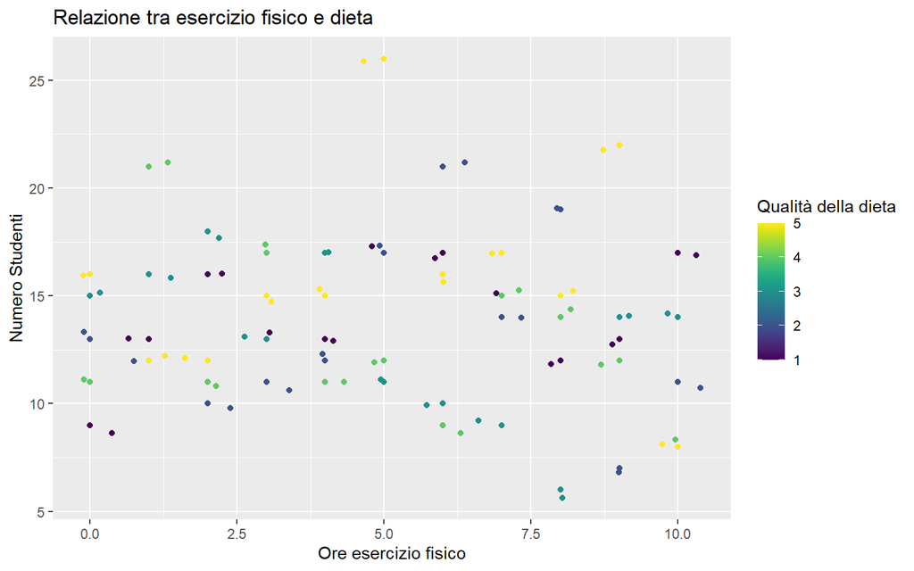

### Meccanismi di Coping

I meccanismi di coping sono un insieme di tecniche che le persone adottano per gestire e risolvere situazioni di stress, che incidono sulle risorse individuali. Tali meccanismi sono fondamentali per mantenere l’equilibrio psicologico e il benessere personale.

Gli studenti, del caso di studio in questione, per fronteggiare situazioni di stress, dovuti da molti fattori, hanno dichiarato di adottare delle strategie di coping come

- Esercizio fisico
- Meditazione
- Lettura
- Yoga
- Utilizzo dei social media
- Spendere del tempo soli
- Parlare con gli amici
- Viaggiare
- Passeggiare, alcuni più nello specifico nella natura
- Guardare lo sport

### Quali sono le strategie più utilizzate negli studenti?

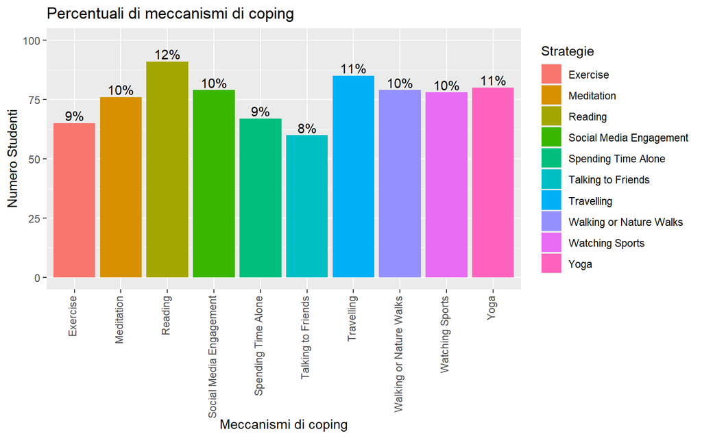

Dal grafico precedente, è possibile osservare che la strategia più utilizzata dagli studenti per alleviare lo stress è la lettura con il 12% degli studenti che adottano questo meccanismo. Inoltre, tutti gli altri tipi di meccanismi sono equamente utilizzati, e solo uno di essi risulta il più basso (parlare con gli amici) con l’8%.

# Conclusioni

Questo progetto si è posto l’obiettivo di analizzare il livello di stress percepito dagli studenti, evidenziando i fattori principali che lo influenzano e le possibili strategie per il benessere accademico e psicologico.

Dall’analisi dei dati è emerso che gli studenti di qualsiasi età e genere possono attraversare periodi di stress, dovuto da diversi fattori come l’aspetto finanziario, relazionale e di paragone con gli altri.

Inoltre, i giovani la maggior parte delle volte sono sopraffatti da distorsioni cognitive che compromettono il rendimento accademico dello stesso, portandolo ad ulteriori situazioni di stress. Infatti, dallo studio dei dati è emerso che queste situazioni compromettono il rendimento degli studenti in alcuni casi.

D’altronde alcuni di questi studenti effettuano delle consulenze che gli permettono di affrontare al meglio determinate situazioni di stress.

Dai dati presi in esame, è venuto fuori che molti giovani cercano di seguire uno stile di vita sano tra esercizio fisico e qualità della dieta, in modo tale da alleviare in qualche modo le diverse situazioni di stress quotidiano.

Infine, è emerso dai dati che gli studenti utilizzano diverse strategie di coping, che gli permettono di gestire o ridurre situazioni stressanti come lo yoga, la meditazione oppure dedicarsi alla lettura.